# PROJECT

Anastasia Buianova

# “Distribution of Number in Russian Constructions with names of Body Parts”

### HSE, Moscow. Course: Data Analysis and Visualisation.

### Content:

1. Introduction;
2. Data Set;
3. Research Hypothesis;
4. Descriptive Statistics and Visualization;
5. Multi-factor analysis;
6. Linguistic interpretation;
7. References.

## 1. Introduction.

This project is made in a frame of my Bachelor and Master research “Constructions with names of body part from the typological perspective”. The main aim of the research is to determine how the body parts are categorized through the prism of constructions. It is expected that the division of the human body into parts represented in constructions does not coincide with the usual concepts that can be obtained from a picture.

The current stage of the research is based only on the Semantic analysis of a whole construction. However, I would like to have a look at some grammatical and morphological features of the constructions. This distribution seems to have a linguistic value as well.

All the Russian constructions in the research are collected in the Russian National Corpus (НКРЯ, ruscorpora.ru) as 2-grams or 3-grams.

## 2. Dataset.

All these features are needed to make a detailed grammatical and morphological analysis of body parts constructions in different languages, that’s why they are in the dataset. As I mentioned above, some of them are irrelevant for this project (such as LANG, BP_NAME, SUBJ/OBJ, VERB, PF/IMPF, DO/IO, PREP, CASE).

MOVEM: BARE, BARE+ORIENT, BEND, CLOSE, DOWN, FALL, FIX, FREE, GLUE, GO, MOVEM, OPEN, OUT, PAINT, RASP, REMOVE, SET, SHAKE, SHOW, SIT, TAKE, THROUGH, TURN, UP, WRAP - “Movements” IDIOM: IDIOM - Idiomatic constructions PLACE: CARRY, LAY, LAY+ORIENT, LAY+STATE, LEAN, LOC, ORIENT, PLACE - “Location” SENSE: BEAT, EMOT, HURT, SENSE, STATE, STAY, TASTE, TOUCH - “Senses, states, and emotions” OTHER: COSM, DIRTY, DRESS, DRESS DOWN, NO CLASS, SPIT, WASH - Other classes that can not be interpreted as movements, senses or location

## 3. Research Hypothesis.

The project hypothesis is that the distribution of body part number (only Sg., only Pl., or both Sg./Pl.) depends on a verb cluster and zone - lower limbs tend to be used more in plural rather than upper limbs.

## 4. Descriptive Statistics, Statistical Significance and Visualization.

### Libraries.

```r
library(tidyverse)
library(vcd)
library(ggrepel)
library(nnet) #Multinominal Logistic Regression
library(FactoMineR) #MCA
library(factoextra) #MCA
```

### Step 1. Norminalizing the dataset.

That’s how the dataset does look. However, as you remember, we don’t need a half of the variables.

```r
#In the case if unicode is broken:
#Sys.setlocale(category = 'LC_ALL', 'en_US.UTF-8')

bp_original <- read_csv('/Users/NP/Desktop/PROJECT/DATASET.csv')
#In the case if the first variant doesn't work:
#bp <- read.csv('/Users/NP/Desktop/DATASET.csv', sep=',')

head(bp_original)
```

```
## # A tibble: 6 x 14
##    LANG       ZONE                    BP_NAME `SUBJ/OBJ`
##   <chr>      <chr>                      <chr>      <chr>
## 1   RUS UPPER LIMB "\u0440\u0443\u043a\u0430"        OBJ
## 2   RUS UPPER LIMB "\u0440\u0443\u043a\u0430"        OBJ
## 3   RUS UPPER LIMB "\u0440\u0443\u043a\u0430"        OBJ
## 4   RUS UPPER LIMB "\u0440\u0443\u043a\u0430"        OBJ
## 5   RUS UPPER LIMB "\u0440\u0443\u043a\u0430"        OBJ
## 6   RUS UPPER LIMB "\u0440\u0443\u043a\u0430"        OBJ
## # ... with 10 more variables: CONSTRUCTIONS <chr>, GROUP <chr>,
## #   VERB <chr>, `PF/IMPF` <chr>, CLASS <chr>, CLUSTER <chr>, NUM <chr>,
## #   `DO/IO` <chr>, PREP <chr>, CASE <chr>
```

So that’s what we actually need now.

```r
bp <- bp_original %>%
  select(2, 5:6, 9:11)

head(bp)
```

```
## # A tibble: 6 x 6
##         ZONE
##        <chr>
## 1 UPPER LIMB
## 2 UPPER LIMB
## 3 UPPER LIMB
## 4 UPPER LIMB
## 5 UPPER LIMB
## 6 UPPER LIMB
## # ... with 5 more variables: CONSTRUCTIONS <chr>, GROUP <chr>,
## #   CLASS <chr>, CLUSTER <chr>, NUM <chr>
```

### Step 2. Descriptive statistics

Here we do look at the general statistics of the data. Table 1 showes the statistical numbers of the grammatical number distribution. There are  
* 142 constructions which might have only plural number (NB: according to the corpus) such as “сшибить с ног”, *“сшибить с ноги”;*  
104 only for singular number such as “задеть плечом”, *“задеть плечами”;*  
and 154 where it’s possible to use both numbers - singular and plural, such as “махать рукой”/“махать руками”.

Table 2 showes how many constructions each of the verb classes has.

Table 3: the same thing as two previous ones, but for verb clusters. There are:  
* 161 constructions with the meaning of movement - “MOVEM” cluster;  
* 108 for senses, states and emotions - “SENSE”;  
* 57 for locations - “PLACE”;  
* 47 idiomatic constructions - “IDIOM”;  
* and 27 are the cluster of “OTHER”."

Tables 4, 5, and 6 show the statistical distribution of the cluster, class, zone and grammatical number in different combinations.

```r
#Table 1.
bp %>%
  group_by(NUM) %>%
  summarise(count=n()) %>%
  arrange(desc(count))
```

```
## # A tibble: 3 x 2
##     NUM count
##   <chr> <int>
## 1 SG/PL   154
## 2    PL   142
## 3    SG   104
```

```r
#Table 2.
bp %>%
  group_by(CLASS) %>%
  summarise(count=n()) %>%
  arrange(desc(count))
```

```
## # A tibble: 49 x 2
##         CLASS count
##         <chr> <int>
##  1      TOUCH    49
##  2      IDIOM    47
##  3      MOVEM    31
##  4       BEAT    25
##  5      SENSE    21
##  6      CARRY    15
##  7      DRESS    14
##  8 DRESS DOWN    11
##  9       WRAP    11
## 10       DOWN    10
## # ... with 39 more rows
```

```r
#Table 3.
bp %>%
  group_by(CLUSTER) %>%
  summarise(count=n()) %>%
  arrange(desc(count))
```

```
## # A tibble: 5 x 2
##   CLUSTER count
##     <chr> <int>
## 1   MOVEM   161
## 2   SENSE   108
## 3   PLACE    57
## 4   IDIOM    47
## 5   OTHER    27
```

```r
#Table 4.
bp %>%
  group_by(CLUSTER, CLASS, NUM) %>%
  summarise(count=n()) %>%
  arrange(NUM, desc(count))
```

```
## # A tibble: 91 x 4
## # Groups:   CLUSTER, CLASS [49]
##    CLUSTER CLASS   NUM count
##      <chr> <chr> <chr> <int>
##  1   IDIOM IDIOM    PL    36
##  2   MOVEM MOVEM    PL    12
##  3   MOVEM  DOWN    PL     9
##  4   SENSE  BEAT    PL     8
##  5   MOVEM SHAKE    PL     6
##  6   MOVEM    UP    PL     6
##  7   SENSE SENSE    PL     6
##  8   SENSE TOUCH    PL     6
##  9   PLACE CARRY    PL     5
## 10   PLACE   LAY    PL     5
## # ... with 81 more rows
```

```r
#Table 5.
bp %>%
  group_by(CLUSTER, NUM) %>%
  summarise(count=n()) %>%
  arrange(NUM, desc(count))
```

```
## # A tibble: 14 x 3
## # Groups:   CLUSTER [5]
##    CLUSTER   NUM count
##      <chr> <chr> <int>
##  1   MOVEM    PL    55
##  2   IDIOM    PL    36
##  3   PLACE    PL    21
##  4   SENSE    PL    21
##  5   OTHER    PL     9
##  6   SENSE    SG    44
##  7   MOVEM    SG    32
##  8   PLACE    SG    13
##  9   IDIOM    SG    11
## 10   OTHER    SG     4
## 11   MOVEM SG/PL    74
## 12   SENSE SG/PL    43
## 13   PLACE SG/PL    23
## 14   OTHER SG/PL    14
```

```r
#Table 6.
bp %>%
  group_by(CLUSTER, ZONE, NUM) %>%
  summarise(count=n()) %>%
  arrange(NUM, desc(count))
```

```
## # A tibble: 21 x 4
## # Groups:   CLUSTER, ZONE [10]
##    CLUSTER       ZONE   NUM count
##      <chr>      <chr> <chr> <int>
##  1   MOVEM UPPER LIMB    PL    38
##  2   IDIOM UPPER LIMB    PL    29
##  3   SENSE UPPER LIMB    PL    18
##  4   MOVEM LOWER LIMB    PL    17
##  5   PLACE LOWER LIMB    PL    12
##  6   PLACE UPPER LIMB    PL     9
##  7   OTHER UPPER LIMB    PL     8
##  8   IDIOM LOWER LIMB    PL     7
##  9   SENSE LOWER LIMB    PL     3
## 10   OTHER LOWER LIMB    PL     1
## # ... with 11 more rows
```

### Step 3. Descriptive statistics visualization.

The graph 1 showes the correlation between a verb cluster and a grammatical number of a used in a construction body part.

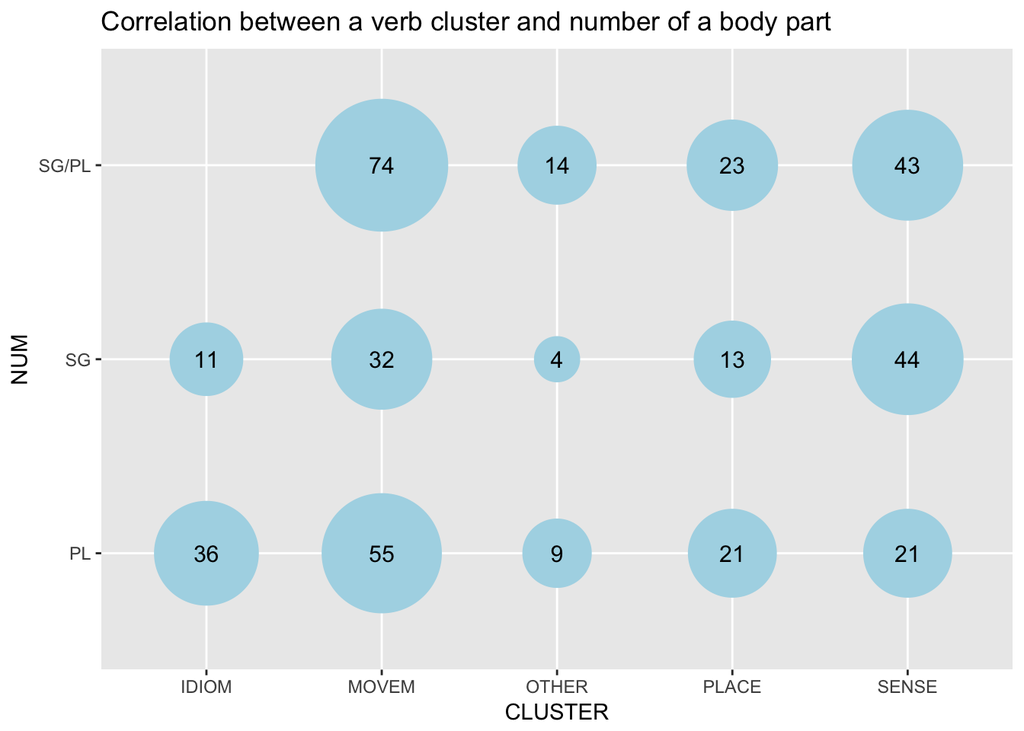

```r
bp %>%
  group_by(CLUSTER, NUM) %>%
  summarise(count=n()) %>%
  ggplot(aes(CLUSTER, NUM, label = count, size = count)) +
  geom_point(aes(size = count), color = "lightblue") +
  geom_text(size = 4) +
  guides(size = F, color = F, fill = F) +
  scale_size(range = c(10, 30)) +
  labs(title = "Correlation between a verb cluster and number of a body part") +
  xlab("CLUSTER") +
  ylab("NUM")
```

The graph 2 showes the correlation between a verb cluster and a grammatical number of a used in a construction body part according to the body zone - lower limbs or upper limbs.

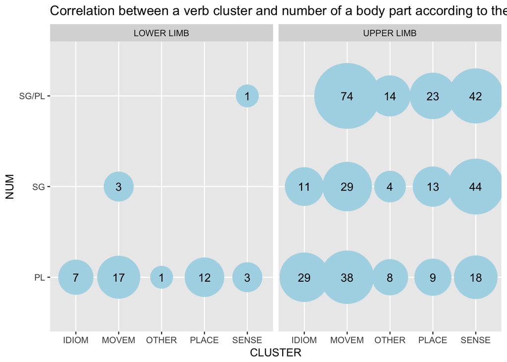

```r
bp %>%
  group_by(CLUSTER, ZONE, NUM) %>%
  summarise(count=n()) %>%
  ggplot(aes(CLUSTER, NUM, label = count, size = count)) +
  geom_point(aes(size = count), color = "lightblue") +
  geom_text(size = 4) +
  guides(size = F, color = F, fill = F) +
  scale_size(range = c(10, 30)) +
  facet_wrap(~ZONE) +
  guides(fill = F) +
  labs(title = "Correlation between a verb cluster and number of a body part according to the body zone") +
  xlab("CLUSTER") +
  ylab("NUM")
```

### Step 4. Statistical significance, Pearson’s Chi-squared Test

On this stage I would like to have a look, if a data I have is actually statistical significant. The main hypothesis of this project is that the distribution of a body part number (Sg., Pl., or Sg./Pl.) depends on a verb cluster and a zone. That’s why I would like to check these two associations CLUSTER ~ NUM, ZONE ~ NUM, and two more to have a look if two previous ones are not the only dependant associations: CLASS ~ NUM, GROUP ~ NUM. I’m goint to use Pearson’s Chi-squared Test.

H0: `CLUSTER` ~ `NUM`, `ZONE` ~ `NUM` are independant H1: `CLUSTER` ~ `NUM`, `ZONE` ~ `NUM` are related.

Same for `CLASS` ~ `NUM`, `GROUP` ~ `NUM`.

```r
#Doesn't seem to be a statistocal significant association due to the small cells value
chisq.test(bp$CLASS, bp$NUM)
```

```
##
##  Pearson's Chi-squared test
##
## data:  bp$CLASS and bp$NUM
## X-squared = 310.88, df = 96, p-value < 2.2e-16
```

```r
chisq.test(bp$CLUSTER, bp$NUM)
```

```
##
##  Pearson's Chi-squared test
##
## data:  bp$CLUSTER and bp$NUM
## X-squared = 65.114, df = 8, p-value = 4.582e-11
```

```r
chisq.test(bp$ZONE, bp$NUM)
```

```
##
##  Pearson's Chi-squared test
##
## data:  bp$ZONE and bp$NUM
## X-squared = 66.605, df = 2, p-value = 3.443e-15
```

```r
#fisher.test(bp$ZONE, bp$NUM)

#Doesn't seem to be a statistocal significant association due to the small cells value
chisq.test(bp$GROUP, bp$NUM)
```

```
##
##  Pearson's Chi-squared test
##
## data:  bp$GROUP and bp$NUM
## X-squared = 146.01, df = 10, p-value < 2.2e-16
```

CLASS ~ NUM, GROUP ~ NUM, to these associations Pearson’s Chi-squared Test can not be applied due to the small cell values in the contingency table (because it can be incorrect). The only trusted pairs are the ones we actually look at CLUSTER ~ NUM, ZONE ~ NUM, for which p-Value is less than 5%. So we reject the null hypothesis and conclude that `CLUSTER`, `ZONE` and `NUM` have a significant relationship (dependant, the data is proved as a statistically significant associations).

## 5. Multi-factor analysis.

### Multinominal Logistic Regression.

Here the multinominal logistic regression model is used to predict ClUSTER by NUM (and later ZONE by NUM). It works like series of logistic regressions, comparing every two levels of an dependant varible.

The first association CLUSTER ~ NUM is not well-predictable (probably due to the lack of the data, for instance for the “OTHER”-cluster the coefficient is -1,4 and it has only 27 contructions from 400).

```r
#For CLUSTER ~ NUM association
cluster_mlg <- multinom(bp$CLUSTER ~ bp$NUM)
summary(cluster_mlg)
```

```
## Call:
## multinom(formula = bp$CLUSTER ~ bp$NUM)
##
## Coefficients:
##       (Intercept)  bp$NUMSG bp$NUMSG/PL
## MOVEM   0.4237528 0.6440683    11.93764
## OTHER  -1.3863356 0.3746870    12.08267
## PLACE  -0.5390858 0.7060668    11.73193
## SENSE  -0.5390619 1.9253125    12.35757
##
## Std. Errors:
##       (Intercept)  bp$NUMSG bp$NUMSG/PL
## MOVEM   0.2143792 0.4100168    56.18621
## OTHER   0.3726750 0.6926727    56.18755
## PLACE   0.2745858 0.4931827    56.18674
## SENSE   0.2745837 0.4347753    56.18656
##
## Residual Deviance: 1066.821
## AIC: 1090.821
```

```r
#For ZONE ~ NUM association
zone_mlg <- multinom(bp$ZONE ~ bp$NUM)
summary(zone_mlg)
```

```
## Call:
## multinom(formula = bp$ZONE ~ bp$NUM)
##
## Coefficients:
##                Values Std. Err.
## (Intercept) 0.9360934 0.1865581
## bp$NUMSG    2.5804148 0.6148481
## bp$NUMSG/PL 4.0943446 1.0204606
##
## Residual Deviance: 208.1048
## AIC: 214.1048
```

### Multiple correspondence analysis (MCA).

```r
cluster_mca <- bp[, 5:6]
clust_res.mca <- MCA(cluster_mca, graph = FALSE)
clust_res.mca
```

```
## **Results of the Multiple Correspondence Analysis (MCA)**
## The analysis was performed on 400 individuals, described by 2 variables
## *The results are available in the following objects:
##
##    name              description
## 1  "$eig"            "eigenvalues"
## 2  "$var"            "results for the variables"
## 3  "$var$coord"      "coord. of the categories"
## 4  "$var$cos2"       "cos2 for the categories"
## 5  "$var$contrib"    "contributions of the categories"
## 6  "$var$v.test"     "v-test for the categories"
## 7  "$ind"            "results for the individuals"
## 8  "$ind$coord"      "coord. for the individuals"
## 9  "$ind$cos2"       "cos2 for the individuals"
## 10 "$ind$contrib"    "contributions of the individuals"
## 11 "$call"           "intermediate results"
## 12 "$call$marge.col" "weights of columns"
## 13 "$call$marge.li"  "weights of rows"
```

```r
clust_res.mca$var
```

```
## $coord
##             Dim 1      Dim 2         Dim 3         Dim 4      Dim 5
## IDIOM  2.15799782  0.5231823  3.823250e-18  3.940803e-01 -0.4268221
## MOVEM -0.16008657 -0.6070353 -9.066677e-01  1.034977e-01  0.4952310
## OTHER -0.27752926 -1.1034726  2.651942e+00  2.154027e+00  0.9002340
## PLACE  0.02552083 -0.2782750  1.163516e+00 -2.129280e+00  0.2270221
## SENSE -0.64456812  1.0999867  7.454283e-02  2.594936e-01 -0.8973901
## PL     1.07430323 -0.2534862  4.472057e-15  8.501566e-15 -0.2067989
## SG    -0.28916510  1.2784555  2.102481e-14 -1.986173e-15  1.0429883
## SG/PL -0.79531096 -0.6296385 -1.959269e-14 -7.028541e-15 -0.5136711
##
## $contrib
##              Dim 1      Dim 2        Dim 3        Dim 4      Dim 5
## IDIOM 40.534222633  2.6783939 1.717525e-34 1.824767e+00  2.6783939
## MOVEM  0.764113117 12.3516311 3.308736e+01 4.311491e-01 12.3516311
## OTHER  0.385126419  6.8447466 4.747138e+01 3.131887e+01  6.8447466
## PLACE  0.006875218  0.9189541 1.929123e+01 6.460712e+01  0.9189541
## SENSE  8.309662612 27.2062743 1.500291e-01 1.818097e+00 27.2062743
## PL    30.350376993  1.8996230 7.099748e-28 2.565820e-27  1.8996230
## SG     1.610449412 35.3895506 1.149311e-26 1.025669e-28 35.3895506
## SG/PL 18.039173595 12.7108264 1.477912e-26 1.901915e-27 12.7108264
##
## $cos2
##              Dim 1      Dim 2        Dim 3        Dim 4       Dim 5
## IDIOM 0.6200477807 0.03644427 1.946204e-36 2.067725e-02 0.024255874
## MOVEM 0.0172638546 0.24823095 5.537634e-01 7.215884e-03 0.165212763
## OTHER 0.0055753546 0.08814102 5.090765e-01 3.358592e-01 0.058663197
## PLACE 0.0001082357 0.01286854 2.249706e-01 7.534357e-01 0.008564793
## SENSE 0.1536662715 0.44752340 2.055193e-03 2.490544e-02 0.297853978
## PL    0.6352174181 0.03536529 1.100736e-29 3.978016e-29 0.023537747
## SG    0.0293787552 0.57426568 1.553123e-28 1.386039e-30 0.382208658
## SG/PL 0.3959675031 0.24818082 2.403110e-28 3.092544e-29 0.165179392
##
## $v.test
##             Dim 1     Dim 2         Dim 3         Dim 4      Dim 5
## IDIOM  15.7289245  3.813301  2.786639e-17  2.872320e+00  -3.110963
## MOVEM  -2.6245529 -9.952093 -1.486444e+01  1.696802e+00   8.119107
## OTHER  -1.4914981 -5.930284  1.425207e+01  1.157617e+01   4.838038
## PLACE   0.2078125 -2.265954  9.474347e+00 -1.733842e+01   1.848608
## SENSE  -7.8302517 13.362703  9.055507e-01  3.152344e+00 -10.901547
## PL     15.9201680 -3.756428  6.627169e-14  1.259852e-13  -3.064565
## SG     -3.4237587 15.137107  2.489369e-13 -2.351658e-14  12.349140
## SG/PL -12.5694484 -9.951088 -3.096515e-13 -1.110822e-13  -8.118287
##
## $eta2
##             Dim 1     Dim 2        Dim 3        Dim 4     Dim 5
## CLUSTER 0.6749755 0.6003984 1.000000e+00 1.000000e+00 0.3996016
## NUM     0.6749755 0.6003984 2.698221e-28 4.570302e-29 0.3996016
```

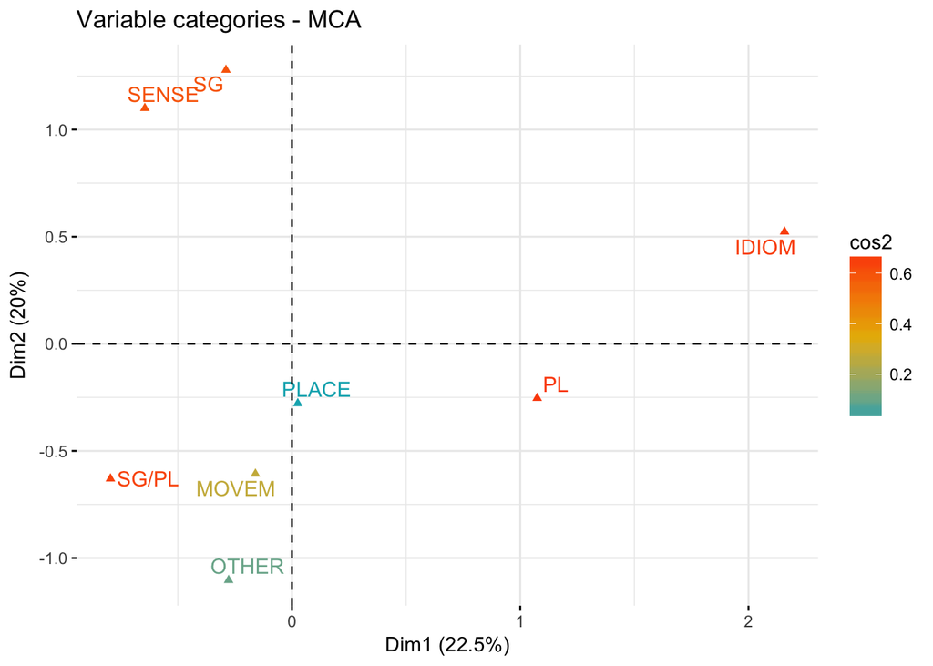

```r
fviz_mca_var(clust_res.mca, col.var = "cos2",
             gradient.cols = c("#00AFBB", "#E7B800", "#FC4E07"),
             repel = TRUE, # Avoid text overlapping (slow)
             ggtheme = theme_minimal())
```

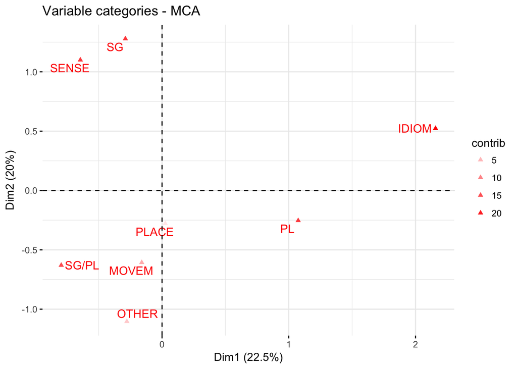

```r
fviz_mca_var(clust_res.mca, alpha.var="contrib",
             repel = TRUE,
             ggtheme = theme_minimal())
```

```r
zone_mca <- bp[, c(1,6)]
zone_res.mca <- MCA(zone_mca, graph = FALSE)
zone_res.mca
```

```
## **Results of the Multiple Correspondence Analysis (MCA)**
## The analysis was performed on 400 individuals, described by 2 variables
## *The results are available in the following objects:
##
##    name              description
## 1  "$eig"            "eigenvalues"
## 2  "$var"            "results for the variables"
## 3  "$var$coord"      "coord. of the categories"
## 4  "$var$cos2"       "cos2 for the categories"
## 5  "$var$contrib"    "contributions of the categories"
## 6  "$var$v.test"     "v-test for the categories"
## 7  "$ind"            "results for the individuals"
## 8  "$ind$coord"      "coord. for the individuals"
## 9  "$ind$cos2"       "cos2 for the individuals"
## 10 "$ind$contrib"    "contributions of the individuals"
## 11 "$call"           "intermediate results"
## 12 "$call$marge.col" "weights of columns"
## 13 "$call$marge.li"  "weights of rows"
```

```r
zone_res.mca$var
```

```
## $coord
##                 Dim 1         Dim 2      Dim 3
## LOWER LIMB  2.3866800  1.205218e-15  1.5474714
## UPPER LIMB -0.2949829  6.791591e-16 -0.1912605
## PL          1.1283033 -9.296443e-02 -0.7315673
## SG         -0.5333221  1.562737e+00  0.3457945
## SG/PL      -0.6802180 -9.696345e-01  0.4410385
##
## $contrib
##                Dim 1        Dim 2     Dim 3
## LOWER LIMB 44.500000 1.597805e-29 44.500000
## UPPER LIMB  5.500000 4.105188e-29  5.500000
## PL         32.096598 3.068047e-01 32.096598
## SG          5.252082 6.349584e+01  5.252082
## SG/PL      12.651320 3.619736e+01 12.651320
##
## $cos2
##                 Dim 1        Dim 2      Dim 3
## LOWER LIMB 0.70402984 1.795287e-31 0.29597016
## UPPER LIMB 0.70402984 3.731989e-30 0.29597016
## PL         0.70068101 4.756661e-03 0.29456233
## SG         0.09993574 8.580518e-01 0.04201242
## SG/PL      0.28965552 5.885749e-01 0.12176954
##
## $v.test
##                 Dim 1         Dim 2      Dim 3
## LOWER LIMB  16.760307  8.463565e-15  10.867019
## UPPER LIMB -16.760307  3.858839e-14 -10.867019
## PL          16.720398 -1.377646e+00 -10.841142
## SG          -6.314615  1.850305e+01   4.094259
## SG/PL      -10.750467 -1.532454e+01   6.970369
##
## $eta2
##          Dim 1        Dim 2     Dim 3
## ZONE 0.7040298 5.702993e-31 0.2959702
## NUM  0.7040298 1.000000e+00 0.2959702
```

## 6. Linguistic interpretation.

The distrubution of grammatical number of body parts statistically depends on the zone, so this part of the project hypothesis is proved. It can be explained with the fact that lower limbs (legs, feet etc.) are usually being used binary as an instrument. There are no a lot of variants of singular usage of a leg or a foot. That we can not apply to the upper limbs (hands, arms, shoulders etc.), which can be a singual instrument as well as a plural instrument.

## 7. References.

Andersen, E. 1978. Lexical universals of body-part terminology. In Universals of Human Language, J. Greenberg (Ed.), 335– 368. Stanford CAC Stanford University Press.  
Bonch-Osmolovskaja, A. A., Merdanova, S. R., Rahilina, E. V., Reznikova. T. I. 2008. “Chastnye tipologii” v leksike: leksicheskoe pole boli. M.  
Bricyn, V. M., Rahilina, E. V., Reznikova, T. I., Javorskaja, G.M. 2009. Koncept bol’ v tipologicheskom osveshhenii. K.: Vidavnichiĭ dіm Dmitra Burago. Chappell, H. & McGregor, W. 1996. (Eds). The Grammar of Inalienability. A Typological Perspective on Body Part Terms and the Part-whole Relation. Berlin: Mouton de Gruyter.  
Enfield, N.J. & Wierzbick,a A. 2002 (Eds). Body in description of emotion. Pragmatics and cognition 10(1–2) (special issue).  
Enfield, N.J. 2002. Semantic analysis of body parts in emotion terminology: Avoiding the exoticisms of ‘obstinate monosemy’ and ‘online extension’. Pragmatics and Cognition 10(1–2): 81–102.  
Enfield, N.J. 2006. Elicitation guide on parts of the body.  
Enfield, N.J., Majid, A. & van Staden, M. 2006. Cross-linguistic categorisation of the body: Introduction. In Majid et al. (Eds), 134–147.  
Fillmore, Ch. J. 1988. The mechanisms of ‘Construction Grammar’ // Proceedings of the Annual Meeting of the Berkeley  
Fillmore, Ch. J. 1989. Grammatical Construction Theory and the familiar dichotomies // R. Dietrich, C. F. Graumann (eds.) Language Processing in Social Context. Amsterdam: North-Holland/Elsevier, 17—38.  
Iomdin L. L. 2015. Konstrukcii mikrosintaksisa, obrazovannye russkoj leksemoj raz), SLAVIA, časopis pro slovanskou filologii, ročník 84, sešit 3, s. 291-306.  
Iordanskaja, L. & Paperno, S. 1996. A Russian-English Collocational Dictionary of the Human Body. Columbus OH: Slavica Publishers. (Also http://LexiconBrige.Com/for the electronic edition).  
Majid, A., Enfield, N.J., & van Staden, M. 2006. (Eds). Parts of the body: Cross-linguistic categorization. Language Sciences 28(2–3): 137–360 (special issue).  
Pavlenko, G. 2002. Emotions and the body in Russian and English. In Enfield & Wierzbicka (Eds), 207–241.  
Rahilina, E. V. 2010. Lingvistika konstrukcij. Azbukovnik, Moskva.  
Rahilina, E. V., Reznikova, T. I. 2013. Frejmovyj podhod k leksicheskoj tipologii. Voprosy jazykoznanija, No2.